# Report Exercise Chapter 10

```r
library(tidyverse)
library(recipes)
library(caret)
library(recipes)
library(rsample)
```

Let’s start with some copy-pasted code from the tutorial (see function `prepare_df`) to set up the data.

```r
source(here::here("R", "prepare_df.R"))

daily_fluxes_dav <- prepare_df(here::here("data", "FLX_CH-Dav_FLUXNET2015_FULLSET_DD_1997-2014_1-3.csv"))
daily_fluxes_lae <- prepare_df(here::here("data", "FLX_CH-Lae_FLUXNET2015_FULLSET_DD_2004-2014_1-4.csv"))
```

Now we create the training/test splits

```r
source(here::here("R", "recipe_daily_fluxes.R"))

# Data splitting
set.seed(123)  # for reproducibility
split_dav <- rsample::initial_split(daily_fluxes_dav, prop = 0.8, strata = "VPD_F")
daily_fluxes_dav_train <- rsample::training(split_dav)
daily_fluxes_dav_test <- rsample::testing(split_dav)

# The same model formulation is in the previous chapter
pp_dav <- daily_fluxes_dav_train |> recipe_daily_fluxes()

split_lae <- rsample::initial_split(daily_fluxes_lae, prop = 0.8, strata = "VPD_F")
daily_fluxes_lae_train <- rsample::training(split_lae)
daily_fluxes_lae_test <- rsample::testing(split_lae)

# The same model formulation is in the previous chapter
pp_lae <- daily_fluxes_lae_train |> recipe_daily_fluxes()
```

## Tuning k

We use the code from the exercises from chapter 10. To be completely accurate, we train two separate models for assessing the differences with two different metrics: MAE and RMSE Most likely, it would not make a large difference if we use MAE for training and then evaluate it on the test set using RMSE but to be completely precise, we do it with separate models.

```r
source(here::here("R", "knn.R"))

set.seed(31052023)

k_grid = data.frame(k = c(2, 5, 10, 15, 20, 25, 30, 35, 40, 60, 100))

mod_dav_mae <- knn_cv(recipe = pp_dav,
                  df_train = daily_fluxes_dav_train |> drop_na(),
                  k_grid = k_grid,
                  metric = "MAE")

mod_lae_mae <- knn_cv(recipe = pp_lae,
                  df_train = daily_fluxes_lae_train |> drop_na(),
                  k_grid = k_grid,
                  metric = "MAE")

# Get optimal k for other metrics
dav_k_rmse <- k_grid$k[which.min(mod_dav_mae$results$RMSE)]
lae_k_rmse <- k_grid$k[which.min(mod_lae_mae$results$RMSE)]

mod_dav_rmse <- knn(recipe = pp_dav,
                  df_train = daily_fluxes_dav_train |> drop_na(),
                  k = dav_k_rmse)

mod_lae_rmse <- knn(recipe = pp_lae,
                  df_train = daily_fluxes_lae_train |> drop_na(),
                  k = lae_k_rmse)
```

```r
# Add modeled predictions to test set
daily_fluxes_dav_test <- daily_fluxes_dav_test |>
  drop_na() %>%  # use magrittr-pipe here for the dot evaluation
  mutate(fit_dav_mae = predict(mod_dav_mae, newdata = .),
         fit_lae_mae = predict(mod_lae_mae, newdata = .),
         fit_dav_rmse = predict(mod_dav_rmse, newdata = .),
         fit_lae_rmse = predict(mod_lae_rmse, newdata = .))

# Add modeled predictions to test set
daily_fluxes_lae_test <- daily_fluxes_lae_test |>
  drop_na() %>%  # use magrittr-pipe here for the dot evaluation
  mutate(fit_lae_mae = predict(mod_lae_mae, newdata = .),
         fit_dav_mae = predict(mod_dav_mae, newdata = .),
         fit_lae_rmse = predict(mod_lae_rmse, newdata = .),
         fit_dav_rmse = predict(mod_dav_rmse, newdata = .))
```

```r
# Calculate in-sample and across-site losses (using caret::MAE, caret::RMSE)
mae_dav_insite <- MAE(daily_fluxes_dav_test$fit_dav_mae,
                      daily_fluxes_dav_test$GPP_NT_VUT_REF)
mae_dav_acrosssite <- MAE(daily_fluxes_lae_test$fit_dav_mae,
                          daily_fluxes_lae_test$GPP_NT_VUT_REF)

rmse_dav_insite <- RMSE(daily_fluxes_dav_test$fit_dav_rmse,
                        daily_fluxes_dav_test$GPP_NT_VUT_REF)

rmse_dav_acrosssite <- RMSE(daily_fluxes_lae_test$fit_dav_rmse,
                                daily_fluxes_lae_test$GPP_NT_VUT_REF)


mae_dav_insite
```

```
## [1] 1.082851
```

```r
mae_dav_acrosssite
```

```
## [1] 2.565779
```

```r
rmse_dav_insite
```

```
## [1] 1.451577
```

```r
rmse_dav_acrosssite
```

```
## [1] 3.215485
```

```r
# Calculate in-site and across-site losses (using caret::MAE, caret::RMSE)
mae_lae_insite <- MAE(daily_fluxes_lae_test$fit_lae_mae,
                      daily_fluxes_lae_test$GPP_NT_VUT_REF)
mae_lae_acrosssite <- MAE(daily_fluxes_dav_test$fit_lae_mae,
                          daily_fluxes_dav_test$GPP_NT_VUT_REF)

rmse_lae_insite <- RMSE(daily_fluxes_lae_test$fit_lae_rmse,
                        daily_fluxes_lae_test$GPP_NT_VUT_REF)
rmse_lae_acrosssite <- RMSE(daily_fluxes_dav_test$fit_lae_rmse,
                            daily_fluxes_dav_test$GPP_NT_VUT_REF)

mae_lae_insite
```

```
## [1] 1.802831
```

```r
mae_lae_acrosssite
```

```
## [1] 1.81543
```

```r
rmse_lae_insite
```

```
## [1] 2.355849
```

```r
rmse_lae_acrosssite
```

```
## [1] 2.314668
```

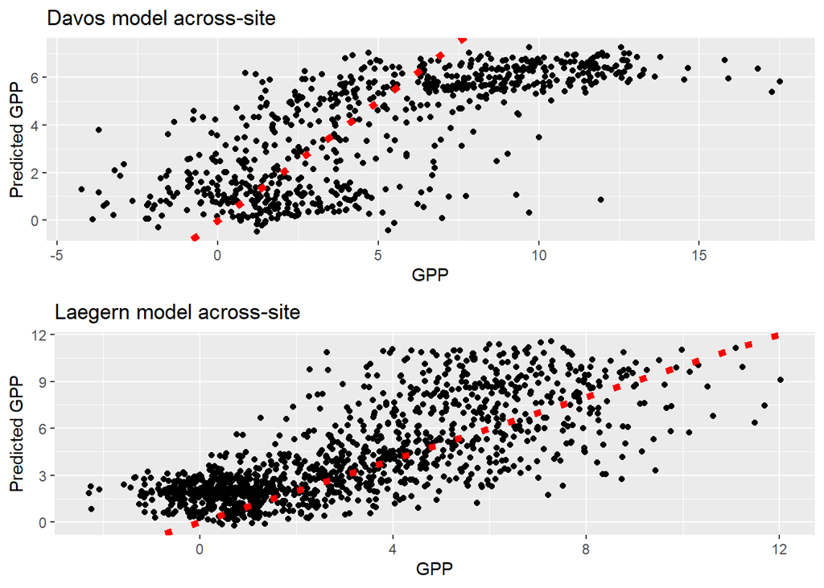

```r
plot_dav_across <- ggplot(
  daily_fluxes_lae_test,
  aes(x = GPP_NT_VUT_REF, y = fit_dav_mae)
) +
  geom_point() +
  labs(x = "GPP",
       y = "Predicted GPP",
       title = "Davos model across-site") +
  geom_abline(slope = 1, intercept = 0, linetype = "dotted",
              linewidth = 2, color = "red")

plot_lae_across <- ggplot(
  daily_fluxes_dav_test,
  aes(x = GPP_NT_VUT_REF, y = fit_lae_mae)
) +
  geom_point() +
  labs(x = "GPP",
       y = "Predicted GPP",
       title = "Laegern model across-site") +
  geom_abline(slope = 1, intercept = 0, linetype = "dotted",
              linewidth = 2, color = "red")

cowplot::plot_grid(plot_dav_across, plot_lae_across, nrow = 2)
```

## Biases

We see that the predictions on Laegern data from the model trained on Davos data are generally *too low*, whereas the predictions on Davos data from the model trained on Laegern data are generally *too high*. Let us investigate it further by taking a look at the distribution of `GPP` at the two places.

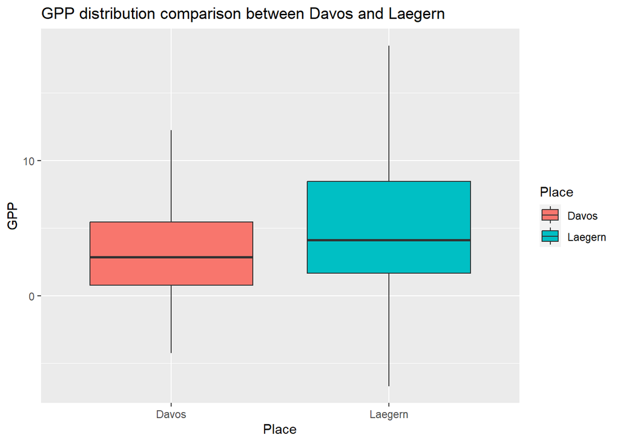

```r
gpp_dav <- tibble(
  PLACE = "Davos",
  GPP_NT_VUT_REF = daily_fluxes_dav$GPP_NT_VUT_REF
)

gpp_lae <- tibble(
  PLACE = "Laegern",
  GPP_NT_VUT_REF = daily_fluxes_lae$GPP_NT_VUT_REF
)

gpp_data <- rbind(gpp_dav, gpp_lae)

ggplot(gpp_data, aes(x = PLACE, y = GPP_NT_VUT_REF, fill = PLACE)) +
  geom_boxplot(na.rm = TRUE) +
  labs(title = "GPP distribution comparison between Davos and Laegern",
       x = "Place",
       y = "GPP",
       fill = "Place")
```

We see that the `GPP` is significantly lower in Davos than in Laegern, so the if the model is trained on Davos data, it leads to generally lower `GPP` predictions. So it will predict values that are too low for Laegern data which is exactly the bias that we observed above.

## Climate analysis

### Davos

Information taken from [here](https://fluxnet.org/sites/siteinfo/CH-Dav). ENF (Evergreen Needleleaf Forests: Lands dominated by woody vegetation with a percent cover >60% and height exceeding 2 meters. Almost all trees remain green all year. Canopy is never without green foliage.)

### Laegern

Information taken from [here](https://fluxnet.org/sites/siteinfo/CH-Lae). MF (Mixed Forests: Lands dominated by trees with a percent cover >60% and height exceeding 2 meters. Consists of tree communities with interspersed mixtures or mosaics of the other four forest types. None of the forest types exceeds 60% of landscape.)

### Comparison

There are some significant differences in terms of temperature, altitude and vegetation. So if we simply put all the data together and handle it as a single data set, it will not be accurate.

Nevertheless, let us set up a data frame that contains all the observations of both Davos and Laegern.

```r
daily_fluxes_full <- bind_rows(daily_fluxes_dav, daily_fluxes_lae)
```

```r
# Combine training sets of Davos and Laegern to a single training set
daily_fluxes_train <- bind_rows(daily_fluxes_dav_train,
                                daily_fluxes_lae_train)
daily_fluxes_test <- bind_rows(daily_fluxes_dav_test,
                               daily_fluxes_lae_test)

# The same model formulation is in the previous chapter
pp <- daily_fluxes_train |> recipe_daily_fluxes()
```

```r
k_grid = data.frame(k = c(2, 5, 10, 15, 20, 25, 30, 35, 40, 60, 100))
mod_full_mae <- knn_cv(recipe = pp,
                  df_train = daily_fluxes_train |> drop_na(),
                  k_grid = k_grid,
                  metric = "MAE")
```

```r
# Evaluate model on Davos test data
daily_fluxes_dav_test <- daily_fluxes_dav_test |>
  drop_na() %>%  # use magrittr-pipe here for the dot evaluation
  mutate(fit_full = predict(mod_full_mae, newdata = .))

# Evaluate model on Laegern test data
daily_fluxes_lae_test <- daily_fluxes_lae_test |>
  drop_na() %>%
  mutate(fit_full = predict(mod_full_mae, newdata = .))

(full_test_dav <- MAE(daily_fluxes_dav_test$fit_full,
                      daily_fluxes_dav_test$GPP_NT_VUT_REF))
```

```
## [1] 1.187124
```

```r
(full_test_lae <- MAE(daily_fluxes_lae_test$fit_full,
                      daily_fluxes_lae_test$GPP_NT_VUT_REF))
```

```
## [1] 1.980342
```

**Comment** We see that the MAE is lower than for the across-site predictions before, but it is higher than the MAE for the in-site predictions. The underlying climate is too different for these two places. That’s why it does not make sense to make a model that was trained on the data of both places together. We have to make separate models to make accurate predictions.

If we really want to train the model using the data of both (or even more places) it could make sense to add a new variable (categorical) to the data indicating the climate at this specific place where the meteorological variables were measured. So places with similar climate would have the same category. Such a model would be more complex but also more accurate.